# CS422 Section 01

Kaiyue Ma

```r
library(cluster)
library(factoextra)
```

```r
library(corrplot)
library(ggplot2)
library(fpc)
library(stringr)
library(tidyr)
setwd("/Users/michael/Codes/R/test")
```

# 2.1

```r
file19 <- read.table("https://people.sc.fsu.edu/~jburkardt/datasets/hartigan/file19.txt", comment.char = "#", skip = 20, strip.white = T, header = T, fill = T, stringsAsFactors = T)

write.csv(file19, file = "file19.csv", row.names = F)
```

## (a)

### (a)(i)

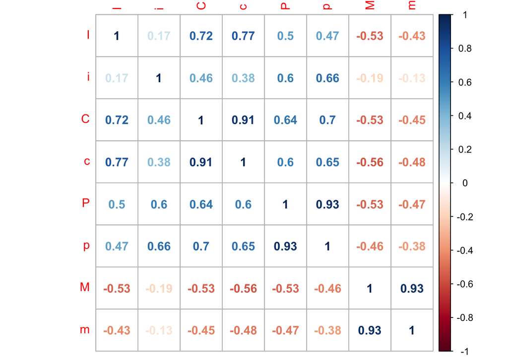

```r
corrplot(round(cor(file19[,2:ncol(file19)]),2),method = "number")
```

```r
cor.test(file19[,2],file19[,3], method = "pearson")
```

```
##
##  Pearson's product-moment correlation
##
## data:  file19[, 2] and file19[, 3]
## t = 1.346, df = 64, p-value = 0.1831
## alternative hypothesis: true correlation is not equal to 0
## 95 percent confidence interval:
##  -0.07930274  0.39219795
## sample estimates:
##       cor
## 0.1659146
```

```r
cor.test(file19[,4],file19[,5], method = "pearson")
```

```
##
##  Pearson's product-moment correlation
##
## data:  file19[, 4] and file19[, 5]
## t = 17.725, df = 64, p-value < 2.2e-16
## alternative hypothesis: true correlation is not equal to 0
## 95 percent confidence interval:
##  0.8589127 0.9450221
## sample estimates:
##       cor
## 0.9114654
```

```r
cor.test(file19[,6],file19[,7], method = "pearson")
```

```
##
##  Pearson's product-moment correlation
##
## data:  file19[, 6] and file19[, 7]
## t = 20.568, df = 64, p-value < 2.2e-16
## alternative hypothesis: true correlation is not equal to 0
## 95 percent confidence interval:
##  0.8909164 0.9579351
## sample estimates:
##       cor
## 0.9319845
```

```r
cor.test(file19[,8],file19[,9], method = "pearson")
```

```
##
##  Pearson's product-moment correlation
##
## data:  file19[, 8] and file19[, 9]
## t = 20.684, df = 64, p-value < 2.2e-16
## alternative hypothesis: true correlation is not equal to 0
## 95 percent confidence interval:
##  0.891991 0.958364
## sample estimates:
##       cor
## 0.9326689
```

#### The attribute “c”,“p”,“m” could be omitted from the dataset, because their correlation value to “C”,“P” and “M” are closed to 1 which implying that these attributes are strongly correlated.

```r
nfile19 <- file19[,c(1,2,3,4,6,8)]
```

### (a)(ii)

```r
nfile19scaled <- scale(nfile19[,2:ncol(nfile19)])
```

#### These data need to be standardized, because different attribute has differnt range. And it’s more effect clustering when the data has already been standardized.

### (a)(iii)

```r
write.csv(nfile19, file = "nfile19.csv", row.names = F)
```

#### Forming new csv named nfile19.csv.

## (b)

### (b)(i)

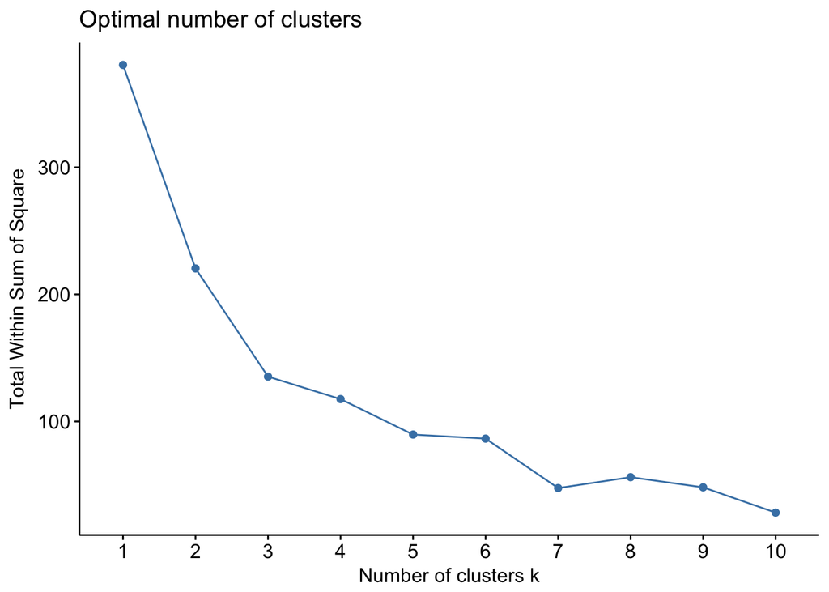

```r
fviz_nbclust(nfile19[2:6], kmeans, method="wss")
```

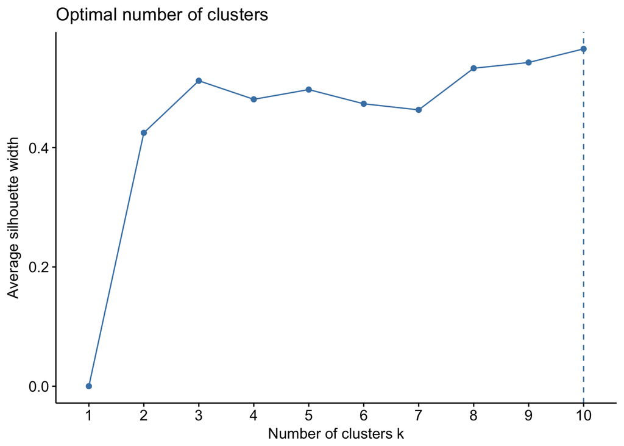

```r
fviz_nbclust(nfile19[2:6], kmeans, method="silhouette")
```

#### I will choice the number of clusters needed are 7, because the slope is almost 0 after 7, in the plot the optimal number of clusters is 10 but the more cluster we choive the more complexity the model will be.

### (b)(ii)

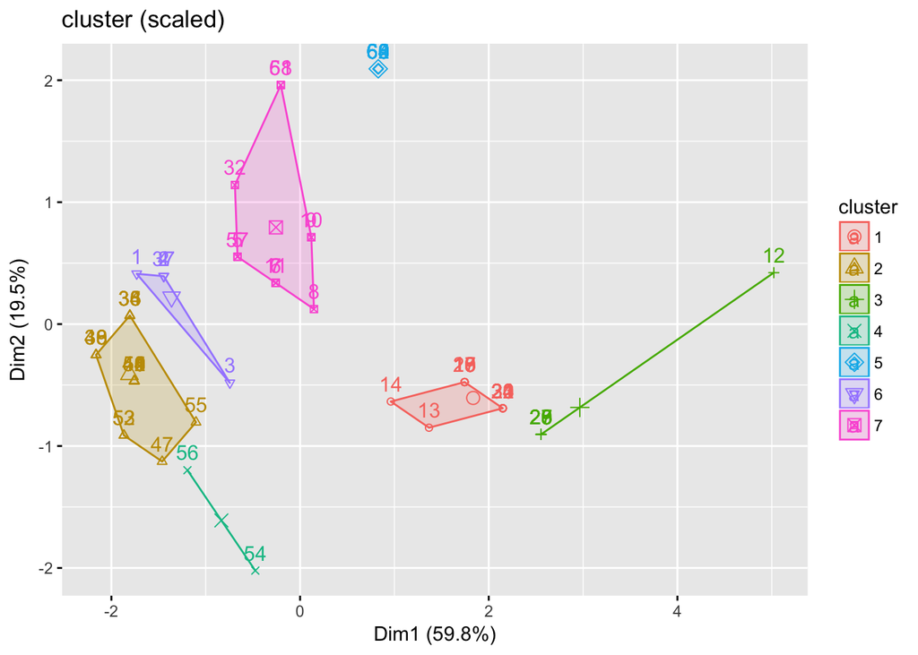

```r
nclass <- kmeans(nfile19scaled, centers = 7)
fviz_cluster(nclass, data=nfile19scaled, main = "cluster (scaled)")
```

### (b)(iii)

```r
print(nclass)
```

```
## K-means clustering with 7 clusters of sizes 14, 21, 6, 2, 7, 5, 11
##
## Cluster means:
##            I          i          C          P          M
## 1 -0.5535871 -1.1881600 -1.1927107 -0.7541593  0.4678196
## 2  1.0037170  0.3711834  0.8257228  0.7523806 -1.0433121
## 3 -0.8131378 -1.3317837 -1.1927107 -2.1041756  1.1825441
## 4 -0.2541056 -1.6190312  0.8257228  0.7719461 -1.6763537
## 5 -1.5119282  1.3970672 -1.1927107  0.3610716  0.4678196
## 6  1.3391364  0.5353248  0.8257228  0.8541210  0.6393535
## 7 -0.3684531  0.6920053  0.8257228 -0.0871552  0.4678196
##
## Clustering vector:
##  [1] 6 6 6 6 7 7 7 7 7 7 7 3 1 1 1 1 1 1 1 1 1 1 1 1 3 3 3 3 3 1 1 7 2 2 2
## [36] 2 6 2 2 2 2 2 2 2 2 2 2 2 2 2 2 2 2 4 2 4 7 7 5 5 7 5 5 5 5 5
##
## Within cluster sum of squares by cluster:
## [1] 4.726482e+00 8.744019e+00 1.652973e+01 1.428316e+00 7.333941e-31
## [6] 5.134126e+00 1.036042e+01
##  (between_SS / total_SS =  85.6 %)
##
## Available components:
##
## [1] "cluster"      "centers"      "totss"        "withinss"
## [5] "tot.withinss" "betweenss"    "size"         "iter"
## [9] "ifault"
```

#### The observation in each cluster is : 14, 21, 6, 2, 7, 5, 11.

### (b)(iv)

```r
print(nclass$tot.withinss)
```

```
## [1] 46.9231
```

#### The total SSE is:46.9231.

### (b)(v)

```r
print(nclass$withinss)
```

```
## [1] 4.726482e+00 8.744019e+00 1.652973e+01 1.428316e+00 7.333941e-31
## [6] 5.134126e+00 1.036042e+01
```

#### SSE in each cluster are:4.726482e+00 8.744019e+00 1.652973e+01 1.428316e+00 7.333941e-31 5.134126e+00 1.036042e+01.

### (b)(vi)

```r
nfile19[which(nclass$cluster == 1),]
```

```
##               Name I i C P M
## 13            Pika 2 1 0 2 3
## 14 Snowshoe rabbit 2 1 0 3 3
## 15          Beaver 1 1 0 2 3
## 16          Marmot 1 1 0 2 3
## 17       Groundhog 1 1 0 2 3
## 18     Prairie Dog 1 1 0 2 3
## 19 Ground Squirrel 1 1 0 2 3
## 20        Chipmunk 1 1 0 2 3
## 21   Gray squirrel 1 1 0 1 3
## 22    Fox squirrel 1 1 0 1 3
## 23   Pocket gopher 1 1 0 1 3
## 24    Kangaroo rat 1 1 0 1 3
## 30       Porcupine 1 1 0 1 3
## 31      Guinea pig 1 1 0 1 3
```

```r
nfile19[which(nclass$cluster == 2),]
```

```
##           Name I i C P M
## 33        Wolf 3 3 1 4 2
## 34         Fox 3 3 1 4 2
## 35        Bear 3 3 1 4 2
## 36   Civet cat 3 3 1 4 2
## 38      Marten 3 3 1 4 1
## 39      Fisher 3 3 1 4 1
## 40      Weasel 3 3 1 3 1
## 41        Mink 3 3 1 3 1
## 42      Ferrer 3 3 1 3 1
## 43   Wolverine 3 3 1 4 1
## 44      Badger 3 3 1 3 1
## 45       Skunk 3 3 1 3 1
## 46 River otter 3 3 1 4 1
## 47   Sea otter 3 2 1 3 1
## 48      Jaguar 3 3 1 3 1
## 49      Ocelot 3 3 1 3 1
## 50      Cougar 3 3 1 3 1
## 51        Lynx 3 3 1 3 1
## 52    Fur seal 3 2 1 4 1
## 53    Sea lion 3 2 1 4 1
## 55   Grey seal 3 2 1 3 2
```

```r
nfile19[which(nclass$cluster == 3),]
```

```
##           Name I i C P M
## 12   Armadillo 0 0 0 0 8
## 25    Pack rat 1 1 0 0 3
## 26 Field mouse 1 1 0 0 3
## 27     Muskrat 1 1 0 0 3
## 28   Black rat 1 1 0 0 3
## 29 House mouse 1 1 0 0 3
```

```r
nfile19[which(nclass$cluster == 4),]
```

```
##             Name I i C P M
## 54        Walrus 1 0 1 3 0
## 56 Elephant seal 2 1 1 4 1
```

```r
nfile19[which(nclass$cluster == 5),]
```

```
##              Name I i C P M
## 59           Deer 0 4 0 3 3
## 60          Moose 0 4 0 3 3
## 62       Antelope 0 4 0 3 3
## 63          Bison 0 4 0 3 3
## 64  Mountain goat 0 4 0 3 3
## 65        Musk ox 0 4 0 3 3
## 66 Mountain sheep 0 4 0 3 3
```

```r
nfile19[which(nclass$cluster == 6),]
```

```
##               Name I i C P M
## 1          Opossum 5 4 1 3 4
## 2  Hairy tail mole 3 3 1 4 3
## 3      Common mole 3 2 1 3 3
## 4   Star nose mole 3 3 1 4 3
## 37         Raccoon 3 3 1 4 3
```

```r
nfile19[which(nclass$cluster == 7),]
```

```
##               Name I i C P M
## 5        Brown bat 2 3 1 3 3
## 6  Silver hair bat 2 3 1 2 3
## 7        Pigmy bat 2 3 1 2 3
## 8        House bat 2 3 1 1 3
## 9          Red bat 1 3 1 2 3
## 10       Hoary bat 1 3 1 2 3
## 11   Lump nose bat 2 3 1 2 3
## 32          Coyote 1 3 1 4 3
## 57         Peccary 2 3 1 3 3
## 58             Elk 0 4 1 3 3
## 61        Reindeer 0 4 1 3 3
```

#### Cluster7 has all C=1 and M=3.

#### Most of the cluster are reasonable, but there still some flaws, such as cluster1 and cluster3 seems should form a large cluster, some animals in cluster2 are supposed to be in cluster4 and in cluster7 bat with some other animal where #58 and #61 should be in cluster 5 which those element are miscluster. The between_SS / total_SS = 85.6 %, which means the model is relatively good and I don’t think it should have more cluster because it will increase the complexity of the model(overfitting) which is a tread-off between the accuracy and the complexity of the model.

# 2.2

```r
lang <- read.table("https://people.sc.fsu.edu/~jburkardt/datasets/hartigan/file46.txt", comment.char = "#", skip = 17, strip.white = T, header = T, fill = T, stringsAsFactors = T)
language <- lang[,-1]
rownames(language) <- lang[,1]
```

## (a)

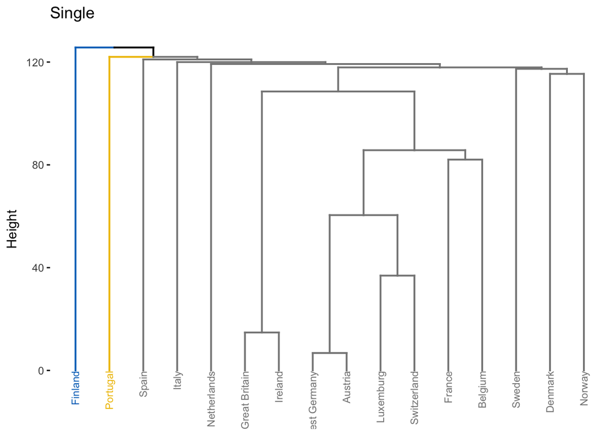

```r
hc.single <- factoextra::eclust(language, "hclust", k = 3, hc_method="single")
fviz_dend(hc.single, show_labels=T, palette="jco", as.ggplot=T, cex=0.6,  main = "Single")
```

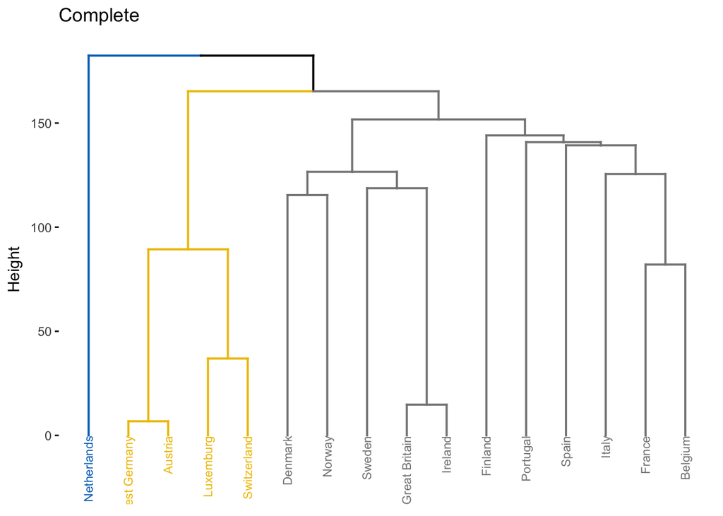

```r
hc.complete <- factoextra::eclust(language, "hclust", k = 3, hc_method="complete")
fviz_dend(hc.complete, show_labels=T, palette="jco", as.ggplot=T, cex=0.6,  main = "Complete")
```

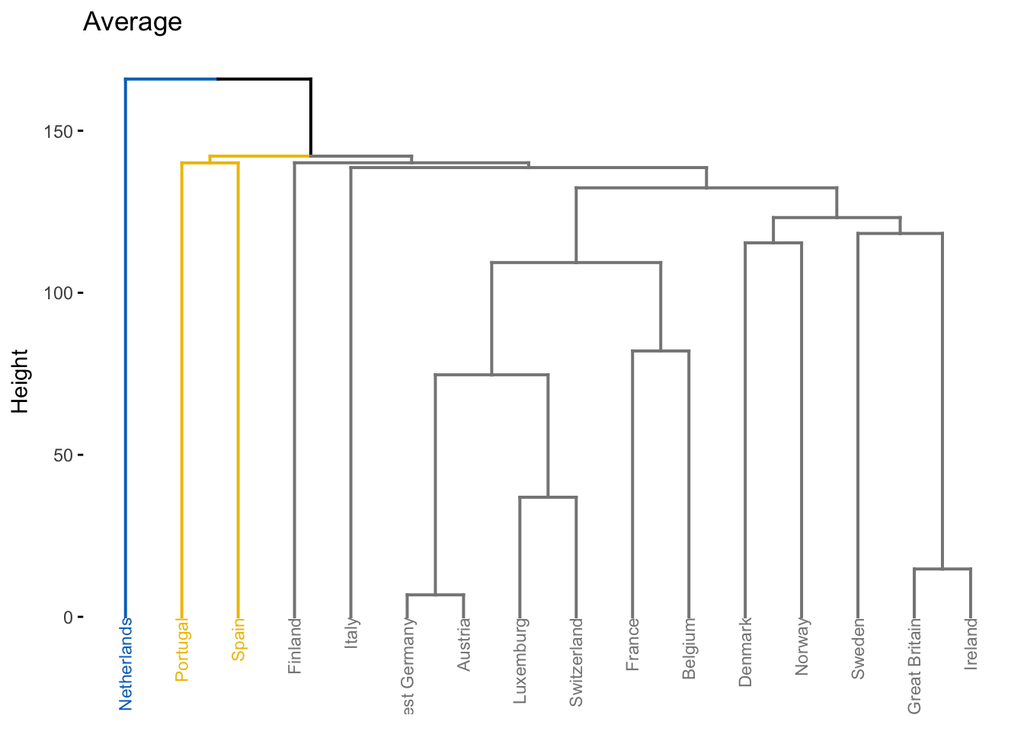

```r
hc.average <- factoextra::eclust(language, "hclust", k = 3, hc_method="average")
fviz_dend(hc.average, show_labels=T, palette="jco", as.ggplot=T, cex=0.6,  main = "Average")
```

## (d)

#### Average linkage method, it generates the most two-singleton cluster(6).

## (e)

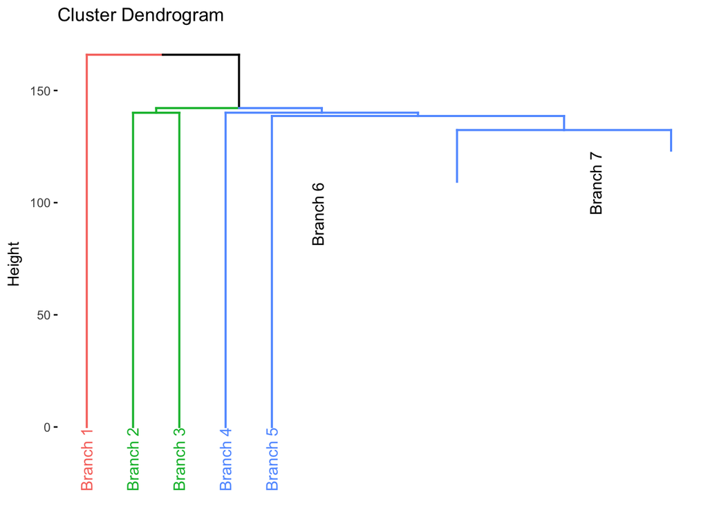

```r
dend_plot <- fviz_dend(hc.average, main = "Average Cluster Dendrogram with height 125", abline(v = 125))
dend_data <- attr(dend_plot,"dendrogram")
dend_cuts <- cut(dend_data,h = 125)
fviz_dend(dend_cuts$upper)
```

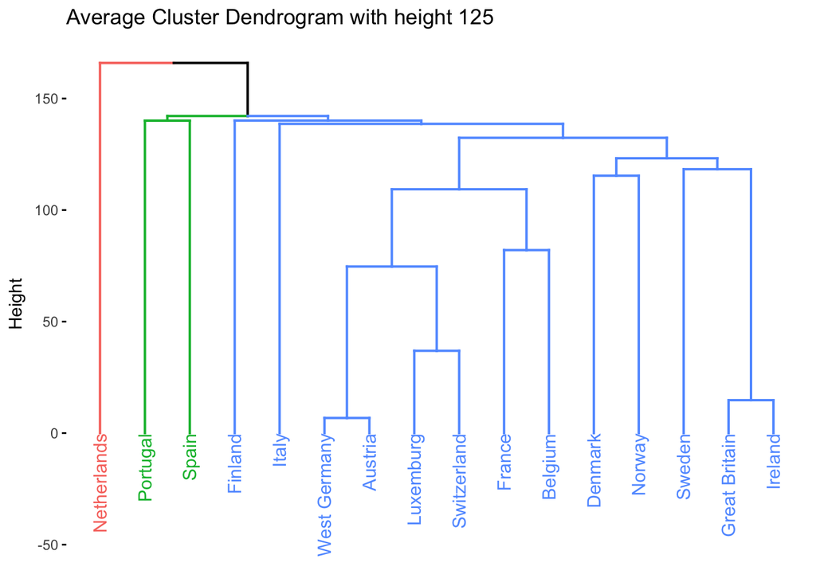

```r
fviz_dend(hc.average, main = "Average Cluster Dendrogram with height 125",labels_track_height = 50)
```

```r
sort(cutree(hc.average, h = 125,  k= NULL))
```

```
##  West Germany        France       Belgium     Luxemburg       Austria
##             1             1             1             1             1
##   Switzerland         Italy   Netherlands Great Britain        Sweden
##             1             2             3             4             4
##       Denmark        Norway       Ireland      Portugal       Finland
##             4             4             4             5             6
##         Spain
##             7
```

#### There would be 7 clusters at a height of 125.

## (f)

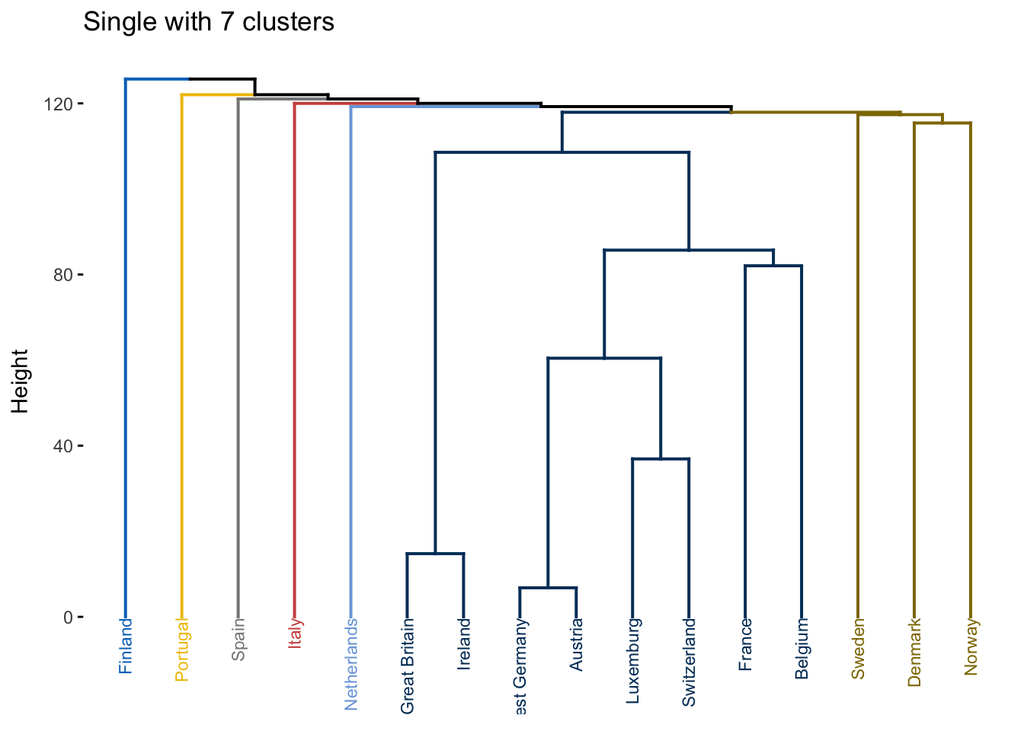

```r
hc.single7 <- factoextra::eclust(language, "hclust", k = 7, hc_method = "single")
fviz_dend(hc.single7, show_labels=T, palette="jco", as.ggplot=T, cex=0.6,  main = "Single with 7 clusters")
```

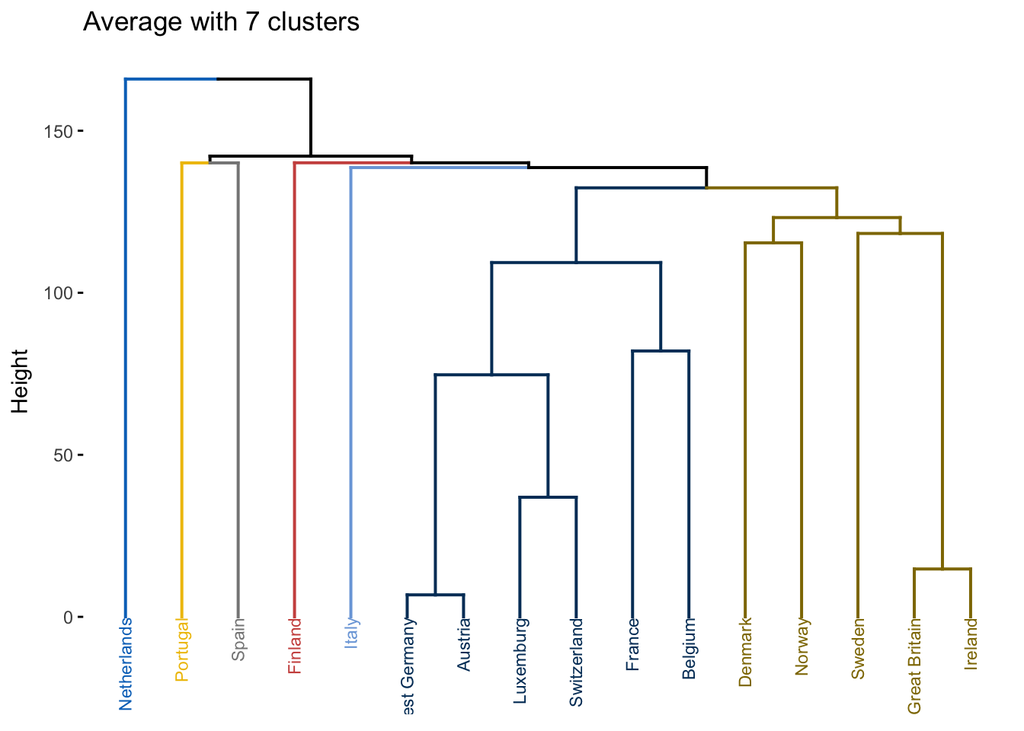

```r
hc.average7 <- factoextra::eclust(language, "hclust", k = 7, hc_method = "average")
fviz_dend(hc.average7, show_labels=T, palette="jco", as.ggplot=T, cex=0.6,  main = "Average with 7 clusters")
```

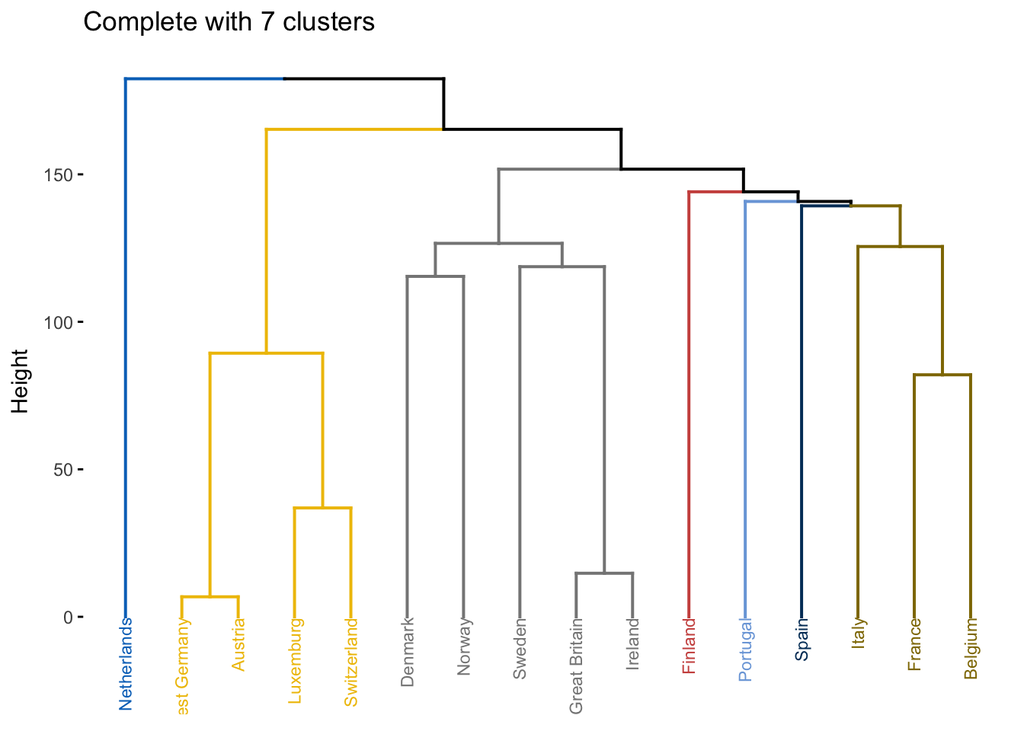

```r
hc.complete7 <- factoextra::eclust(language, "hclust", k = 7, hc_method = "complete")
fviz_dend(hc.complete7, show_labels=T, palette="jco", as.ggplot=T, cex=0.6,  main = "Complete with 7 clusters")
```

## (g)

```r
dunn_hc.single7 <- cluster.stats(dist(language), hc.single7$cluster)["dunn"]
avgsil_hc.single7 <- cluster.stats(dist(language), hc.single7$cluster)["avg.silwidth"]
as.numeric(dunn_hc.single7)
```

```
## [1] 0.7813006
```

```r
as.numeric(avgsil_hc.single7)
```

```
## [1] 0.1215148
```

```r
dunn_hc.average7 <- cluster.stats(dist(language), hc.average7$cluster)["dunn"]
avgsil_hc.average7 <- cluster.stats(dist(language), hc.average7$cluster)["avg.silwidth"]
as.numeric(dunn_hc.average7)
```

```
## [1] 0.807345
```

```r
as.numeric(avgsil_hc.average7)
```

```
## [1] 0.1698248
```

```r
dunn_hc.complete7 <- cluster.stats(dist(language), hc.complete7$cluster)["dunn"]
avgsil_hc.complete7 <- cluster.stats(dist(language), hc.complete7$cluster)["avg.silwidth"]
as.numeric(dunn_hc.complete7)
```

```
## [1] 0.6768822
```

```r
as.numeric(avgsil_hc.complete7)
```

```
## [1] 0.1922308
```

#### Single linkage:

#### Dunn: 0.7813006; Average Silhouette width: 0.1215148

#### Average linkage:

#### Dunn: 0.807345 ; Average Silhouette width: 0.1698248

#### Complete linkage:

#### Dunn: 0.6768822; Average Silhouette width: 0.1922308

## (h)

#### Aaverage linkage is the best cluter based on the Dunn index.

## (i)

#### Complete linkage is the best cluter based on the Average Silhouette Width.

# 2.3

```r
htru2 <- read.csv("HTRU_2-small.csv", header=T, sep=",")
htru2scaled <- scale(htru2)
```

## (a)

```r
pca <- prcomp(htru2scaled[,1:8])
pca
```

```
## Standard deviations (1, .., p=8):
## [1] 2.0390930 1.4580613 0.8975401 0.6742584 0.5111361 0.3984421 0.1434342
## [8] 0.1239556
##
## Rotation (n x k) = (8 x 8):
##                        PC1        PC2         PC3         PC4          PC5
## mean             0.3621185 -0.3557532 -0.01903077 -0.28110182  0.751127908
## std.dev          0.2113048 -0.4360516  0.42887573  0.75850013  0.011659622
## kurtosis        -0.4152927  0.3181695  0.09423843  0.30579508  0.142778760
## skewness        -0.3982761  0.3111845  0.08440847  0.18828876  0.638696703
## mean.dm.snr     -0.3410716 -0.2537362  0.57746591 -0.34179528 -0.065190989
## std.dev.dm.snr  -0.3883051 -0.3139829  0.22917201 -0.24818696 -0.053784780
## kurtosis.dm.snr  0.3720056  0.4072348  0.27735030 -0.03326659  0.000972254
## skewness.dm.snr  0.2960231  0.3955042  0.58033429 -0.19279159 -0.014424030
##                         PC6          PC7          PC8
## mean            -0.02210498 -0.313434107  0.002602825
## std.dev         -0.04150390  0.063675726  0.006273999
## kurtosis        -0.04444483 -0.775594182  0.001057761
## skewness         0.02799052  0.541395908  0.011682875
## mean.dm.snr      0.59623381 -0.032101651  0.090675620
## std.dev.dm.snr  -0.75929114  0.043036463  0.235051714
## kurtosis.dm.snr -0.02144172 -0.009069735  0.785620005
## skewness.dm.snr -0.25010489  0.009147940 -0.564930160
```

### (a)(i)

```r
summary(pca)
```

```
## Importance of components:
##                           PC1    PC2    PC3     PC4     PC5     PC6
## Standard deviation     2.0391 1.4581 0.8975 0.67426 0.51114 0.39844
## Proportion of Variance 0.5197 0.2657 0.1007 0.05683 0.03266 0.01984
## Cumulative Proportion  0.5197 0.7855 0.8862 0.94301 0.97566 0.99551
##                            PC7     PC8
## Standard deviation     0.14343 0.12396
## Proportion of Variance 0.00257 0.00192
## Cumulative Proportion  0.99808 1.00000
```

#### The first two components are explained 78.55%

### (a)(ii)

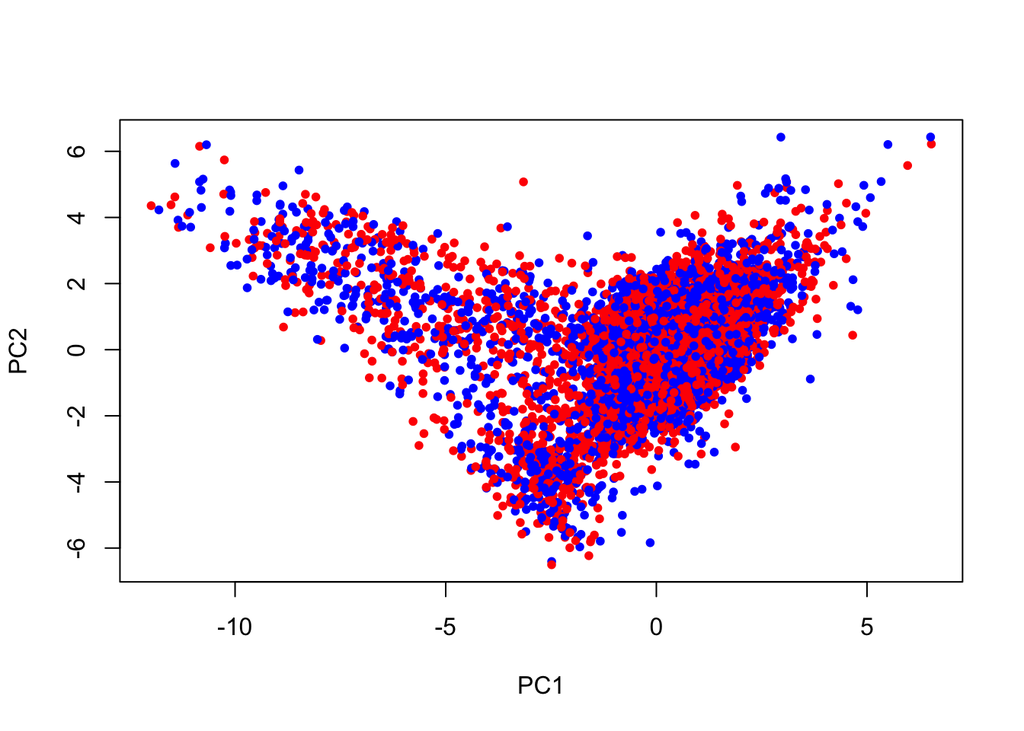

```r
raw <- pca$x[,1:2]
plot(raw[,1], raw[,2], col= c("blue", "red"), pch=20, xlab = "PC1", ylab = "PC2")
```

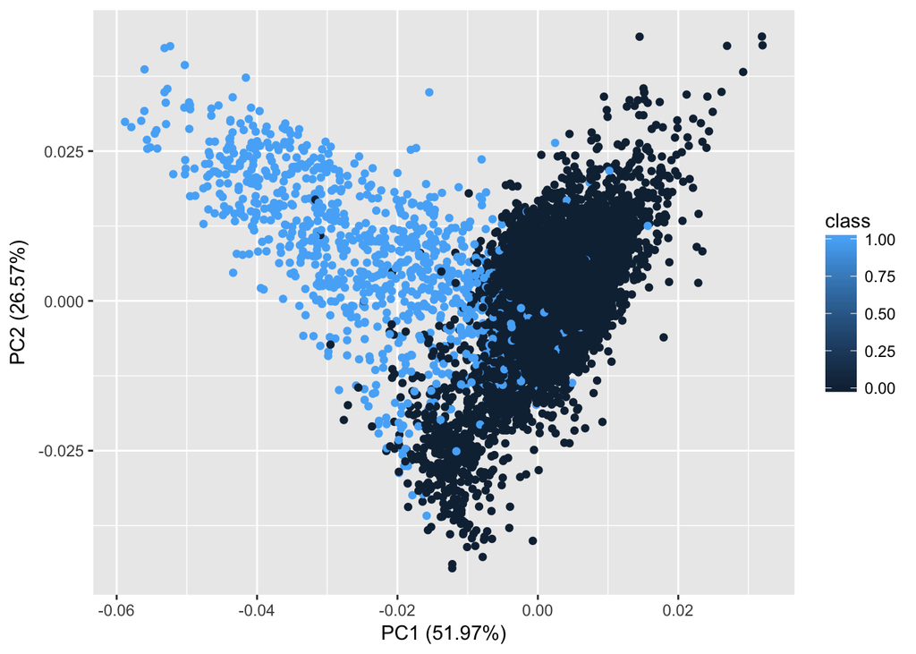

```r
library(ggfortify)
htru2pc <- prcomp(htru2[,-9], scale. = T)
ggplot2::autoplot(htru2pc, data = htru2, colour = "class")
```

### (a)(iii)

#### In the 2nd plot.In the middle part of the plot shows up some overlaped. left is Class1 and right on is Class0.

## (b)

### (b)(i)

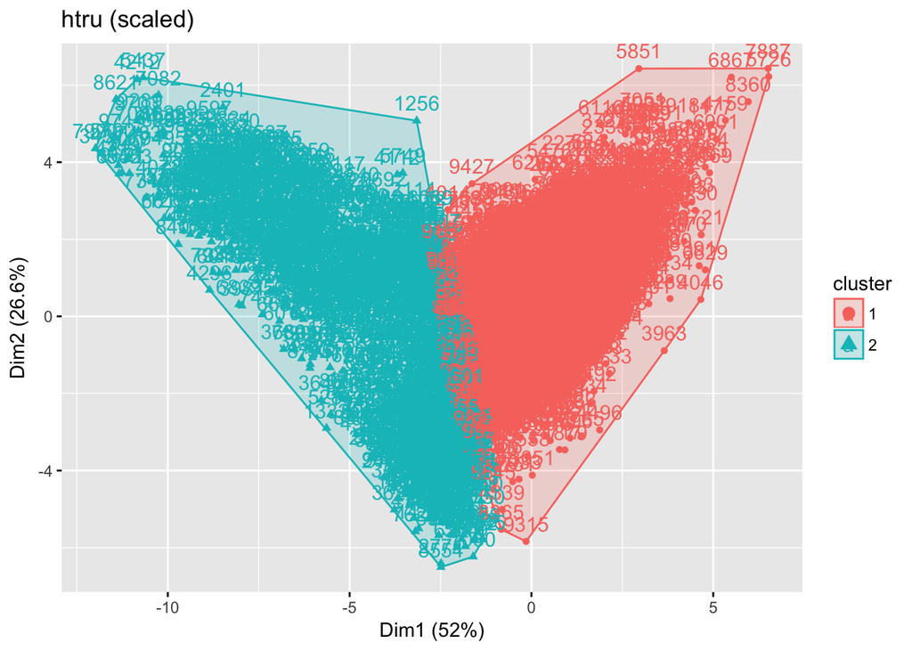

```r
kmean_htru2 <- kmeans(htru2scaled[,1:8], centers = 2)
fviz_cluster(kmean_htru2, data = htru2scaled[,1:8], main = "htru (scaled)")
```

### (b)(ii)

#### Yes they are similar. Because b(i) shows the cluster and a(ii) shows the real data.The difference between them is :the two clusters in (a) ii are based on the value of the Principal Component Score of the HTRU2-small data and the two clusters in (b) i, are based on the closest distance to the cluster centroid. Additionally, In the cluster from (b) i, we observe that there is a clear line of demarcation between the two clusters, however, in (a) ii. there is no clear demarcation of the observations.

### (b)(iii)

```r
sum(kmean_htru2$cluster == 1)
```

```
## [1] 8847
```

```r
sum(kmean_htru2$cluster == 2)
```

```
## [1] 1153
```

#### The distribution of cluster1 is 8847 and cluster2 is 1153.

### (b)(iv)

```r
sum(htru2$class == 0)
```

```
## [1] 9041
```

```r
sum(htru2$class == 1)
```

```
## [1] 959
```

#### The distribution of class0 is 9041 and class1 is 959.

### (b)(v)

#### Cluster1 corresponds to the majority class, Cluster2 corresponds to the minority class.

### (b)(vi)

```r
a <- which(kmean_htru2$cluster == 1)
sum(htru2[a,"class"] == 0)
```

```
## [1] 8624
```

```r
sum(htru2[a,"class"] == 1)
```

```
## [1] 223
```

### (b)(viii)

```r
print(kmean_htru2)
```

```
## K-means clustering with 2 clusters of sizes 8847, 1153
##
## Cluster means:
##         mean     std.dev   kurtosis  skewness mean.dm.snr std.dev.dm.snr
## 1  0.1910945  0.07626496 -0.2377641 -0.220951  -0.2870852     -0.2884001
## 2 -1.4662733 -0.58518308  1.8243700  1.695363   2.2028122      2.2129014
##   kurtosis.dm.snr skewness.dm.snr
## 1       0.2112272       0.1266174
## 2      -1.6207523      -0.9715384
##
## Clustering vector:
##     [1] 2 1 2 1 1 1 1 1 1 1 1 1 1 2 1 1 1 1 1 1 1 1 2 1 1 1 1 1 2 1 1 1 1 2
##    [35] 1 1 1 1 1 1 1 1 1 1 1 1 1 1 1 1 1 1 1 1 1 1 1 1 1 1 1 1 2 1 1 1 2 1
##    [69] 1 1 2 2 2 1 2 2 1 1 1 1 1 1 2 1 1 2 1 1 1 2 1 1 1 2 2 1 1 1 2 2 1 1
##   [103] 2 1 1 1 1 1 1 1 1 1 1 1 1 1 1 1 1 2 1 2 1 1 1 1 1 1 1 1 1 1 1 1 1 1
```

[output cut: 301 more lines]

#### 35.9% variance is explained by the clustering.

### (b)(ix)

```r
status <- cluster.stats(dist(htru2scaled), kmean_htru2$cluster, silhouette = T)
status$avg.silwidth
```

```
## [1] 0.6125963
```

#### The average Silhouette width of both the clusters is 0.6125963.

### (b)(x)

```r
status$clus.avg.silwidths
```

```
##         1         2
## 0.6723086 0.1544215
```

#### Cluster1 is better because it has higher Silhouette width.

## (c)

### (c)(i)

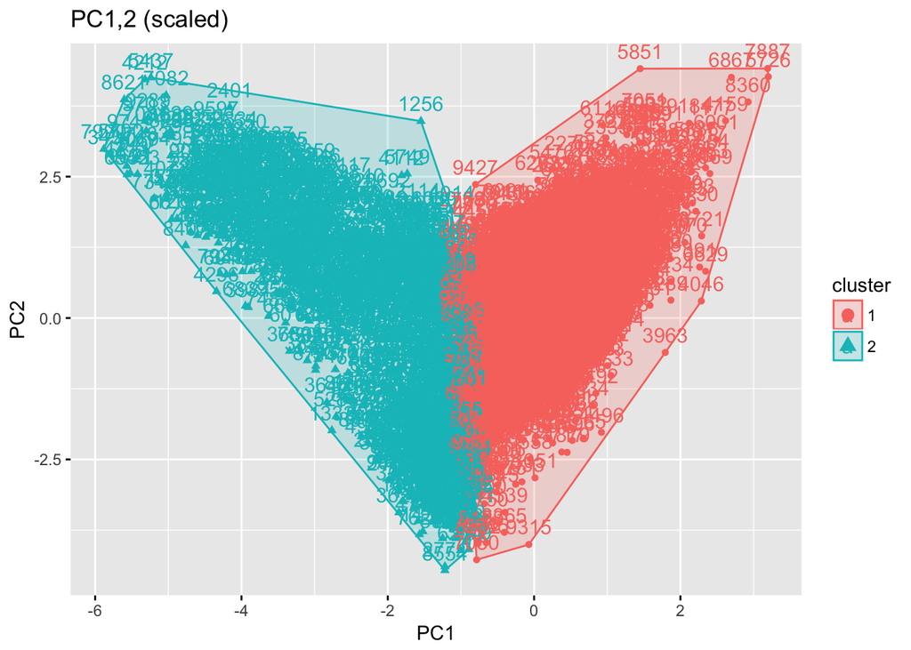

```r
kmean_htru2_12 <- kmeans(pca$x[,1:2], centers = 2)
fviz_cluster(kmean_htru2_12, data = pca$x[,1:2], main = "PC1,2 (scaled)")
```

#### All of these three plot has same shape. c(i) and b(i) are similar but the dividing line in c(i) looks more vertival.

### (c)(ii)

```r
status1 <- cluster.stats(dist(pca$x[,1:2]), kmean_htru2_12$cluster, silhouette = T)
status1$avg.silwidth
```

```
## [1] 0.6494315
```

#### The average Silhouette width of both the clusters is 0.6494315.

### (c)(iii)

```r
status1$clus.avg.silwidths
```

```
##         1         2
## 0.7039929 0.2291330
```

#### Cluster1 is better because it has higher Silhouette width.

### (c)(iv)

#### Average silhouette width values of c(ii) and c(iii) are larger than b(ix) and b(x) which means in c it has better cluster. Also the average silouette width of better cluster are increased.